# **MolDia** Single cell In-Situ RCA data analysis

Mats Nilsson* Department of Biochemistry and Biophysics Stockholm University, Sweden

# 1 Introduction

This is a complete package to analyze single cell in-sutu RCA data analysis.

# 2 Package outline

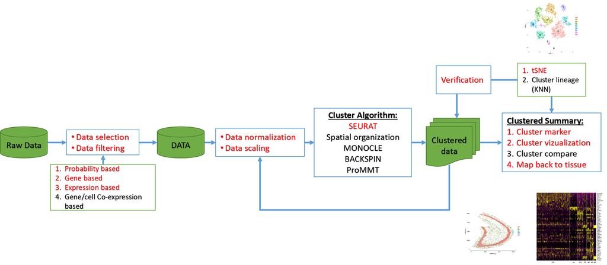

# 3 Data structure

## 3.1 Raw data

The raw data obtained from image analysis pipeline. The generic data structure for RCA in-situ is as follows in xlsx or csv formated file

```
##      CellId Cdh13 Chodl Chrm2 Cnr1 Cort Cox6a2 centroid_x centroid_y
## 1  cellid_1     0     0     0    0    0      0        115       2660
## 2  cellid_2     0     0     0    0    0      0        117       2630
## 3  cellid_4     0     0     0    0    0      0        149       2560
## 4  cellid_9     0     0     0    0    0      0        171       2890
## 5 cellid_10     0     0     0    0    0      0        180       2590
## 6 cellid_11     0     0     0    0    0      1        188       2930
```

# 4 Reading data and vizualization

## 4.1 Read RCA data

The raw RCA data can be read by function `readRCA`. To get help on the function write `help(readRCA)`. The data read by function `readRCA` will be in class `RCA_class`. For more help on this class, write `help(RCA_class)`.

```r
library(MolDia)
ex_data <- readRCA(file = system.file("extdata", "Hypocampus_left.csv", package="MolDia"),
                  cellid = "CellId", centX = "centroid_x", centY = "centroid_y")
ex_data
```

```
## An object of class RCA_class
## Number of genes: 84
## Number of cells: 5661
## Cluster id:
## Cluster size:
```

## 4.2 Vizualization and summary of RCA data

### 4.2.1 Plot RCA data

```r
RCA_map(data =ex_data, what = "cell", main = "Left Hippocampus")
```

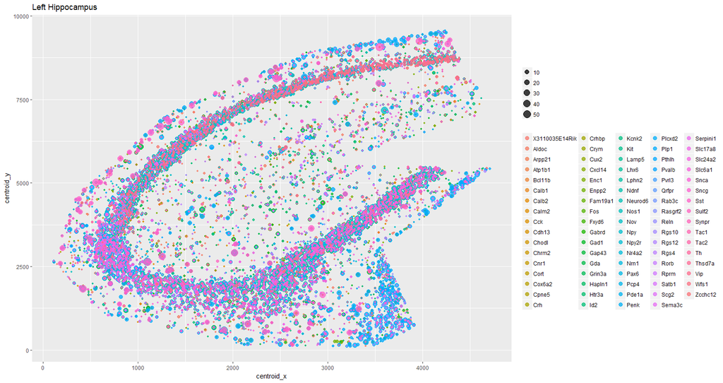

### 4.2.2 Summary of RCA data

Now we have got the raw RCA data in R. Now we can observed some basic summary statistics about our data which will provide some insight about the data. And based on thses summary we can apply prespective of different analysis.

The function `readsSummary` will be used to get the summary of data. Number of reads per cell is a importent feature of the data. So what will be the minimum number of reads per cell to be consider is an important issue. By using parameter `readlimit` in the function `readsSummary`, we can observe the effect.

```r
ex_data_summary   <- readsSummary(data = ex_data, readlimit = 10, text.size = 6,
                                  intervel.dep = c(5,20,40,60))
```

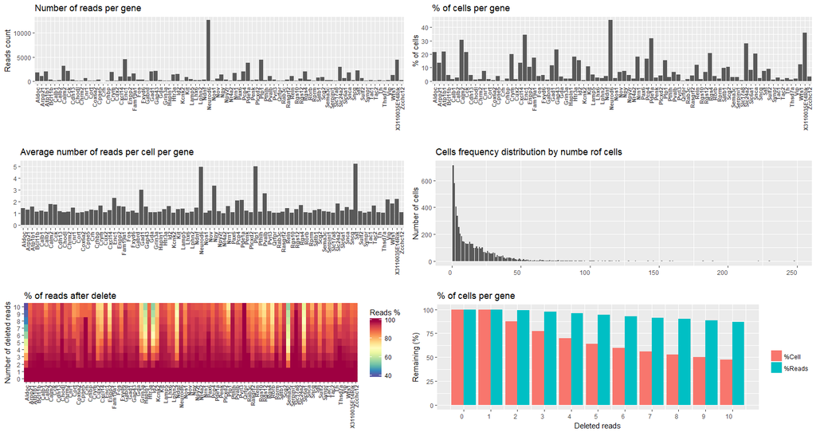

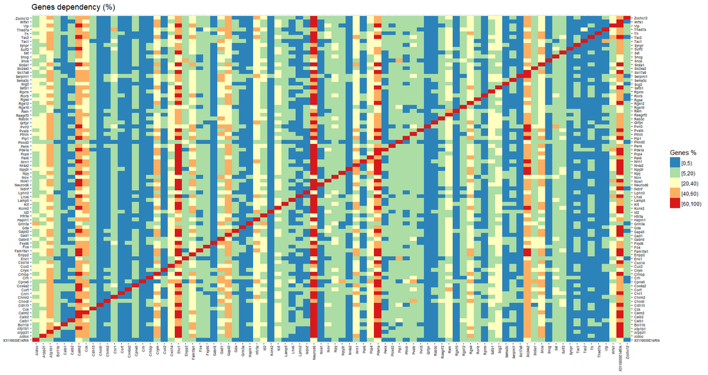

# 5 Gene co expression analysis

## 5.1 WGCNA

## 5.2 Venn-pieagram single cell vizualization

The ven-pie plot is a visual representaion of RCA data, based on genes of interest. As example, we want to know proportional dependency of SST-interneuronal genes enrich cells. For details about the function see `help(RCA_pieplot)`

```r
data(marker_gene)
sst <- marker_gene[[5]]
```

```
##  [1] "Sst"    "Chodl"  "Npy"    "Reln"   "Satb1"  "Grin3a" "Cort"
##  [8] "Crhbp"  "Th"     "Synpr"
```

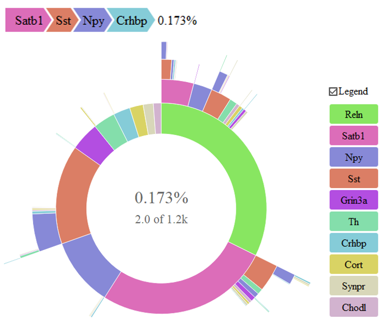

```r
res <- RCA_pieplot (data = ex_data, gene = sst)
```

# 6 Custom criteria based cell selection

There are several way to filter out data/cell. The following are the some are way to filter out cells

1. Filter cells by outlier detection
2. Filter cells by gene criteria

## 6.1 Filter cells by outlier detection

Distribution of cells by total numbe of reads, shows exponential pattern. Thats means, there are lot of cells with very low (1 reads/cell) number of reads and very few cells this high number of reads. So we need to filter those few cells with high number of reads, which can significantly influence our data at processing (In data scaling, centering and normalization) step.

### 6.1.1 Probability based data filtering: Poisson Distibution

[Note: Not working good rignt now. Need to do more optimization]

To filter extreme data, `RCA_filter` function will be used. This function estimate the probabity of number of reads per cell in a specific range with desired mean (Rate or number or reads per cell) by Poisson distibution. By default current fuction calculate the mean from data and return number of reads percell between a range with probability. Output of this function is dataset in class `RCA_class`.

```r
ex_data_1    <- RCA_filter(data = ex_data)
```

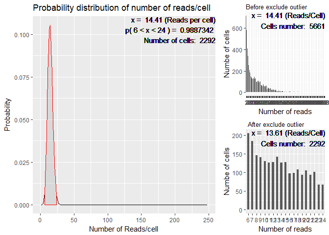

```r
ex_data_2    <- RCA_filter(data = ex_data, data_mean = 7)
```

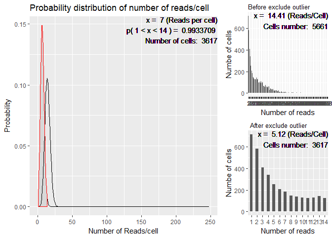

## 6.2 Filter cells by gene criteria

### 6.2.1 Define gene group

Based on different criteria or condition, on can filter data with the function `RCA_barplot` For detail about the function write `help(RCA_barplot)`. This function will have output in class `RCA_class`.

```r
## Load data
RCA_data    <- ex_data
```

The loaded data is from mouse brain left hipoampus. Genes present in that data is

```r
marker_gene_1 <- RCA_data@gene
marker_gene_1
```

```
##  [1] "X3110035E14Rik" "Aldoc"          "Arpp21"         "Atp1b1"
##  [5] "Bcl11b"         "Calb1"          "Calb2"          "Calm2"
##  [9] "Cck"            "Cdh13"          "Chodl"          "Chrm2"
## [13] "Cnr1"           "Cort"           "Cox6a2"         "Cpne5"
## [17] "Crh"            "Crhbp"          "Crym"           "Cux2"
## [21] "Cxcl14"         "Enc1"           "Enpp2"          "Fam19a1"
## [25] "Fos"            "Fxyd6"          "Gabrd"          "Gad1"
## [29] "Gap43"          "Gda"            "Grin3a"         "Hapln1"
## [33] "Htr3a"          "Id2"            "Kcnk2"          "Kit"
## [37] "Lamp5"          "Lhx6"           "Lphn2"          "Ndnf"
## [41] "Neurod6"        "Nos1"           "Nov"            "Npy"
## [45] "Npy2r"          "Nr4a2"          "Nrn1"           "Pax6"
## [49] "Pcp4"           "Pde1a"          "Penk"           "Plcxd2"
## [53] "Plp1"           "Pthlh"          "Pvalb"          "Pvrl3"
## [57] "Qrfpr"          "Rab3c"          "Rasgrf2"        "Reln"
## [61] "Rgs10"          "Rgs12"          "Rgs4"           "Rorb"
## [65] "Rprm"           "Satb1"          "Scg2"           "Sema3c"
## [69] "Serpini1"       "Slc17a8"        "Slc24a2"        "Slc6a1"
## [73] "Snca"           "Sncg"           "Sst"            "Sulf2"
## [77] "Synpr"          "Tac1"           "Tac2"           "Th"
## [81] "Thsd7a"         "Vip"            "Wfs1"           "Zcchc12"
```

According to our pre knowlidge, we can classify those genes in borad category as follows

```r
## This data set has provided with the package as sample informatio.
data(marker_gene)
```

```
## $genr
## [1] "Slc6a1" "Lhx6"   "Gad1"
##
## $genr_neuro
##  [1] "Cdh13"   "Slc24a2" "Gda"     "Lphn2"   "Bcl11b"  "Calb1"   "Atp1b1"
##  [8] "Rgs4"    "Pde1a"   "Penk"
##
## $genr_neuro_pyra1
##  [1] "Nrn1"           "Pcp4"           "Rprm"           "Enpp2"
##  [5] "Rorb"           "Rasgrf2"        "Wfs1"           "Fos"
##  [9] "Plcxd2"         "Crym"           "X3110035E14Rik" "Pvrl3"
##
## $genr_neuro_pyra2
## [1] "Cux2"  "Kcnk2" "Nr4a2"
##
## $genr_neuro_inter1
##  [1] "Sst"    "Chodl"  "Npy"    "Reln"   "Satb1"  "Grin3a" "Cort"
##  [8] "Crhbp"  "Th"     "Synpr"
##
## $genr_neuro_inter2
## [1] "Pvalb"  "Chrm2"  "Tac1"   "Thsd7a"
##
## $genr_neuro_inter3
## [1] "Ndnf"   "Hapln1" "Kit"    "Gabrd"  "Rab3c"  "Nos1"   "Lamp5"
##
## $genr_neuro_inter4
## [1] "Cxcl14" "Cpne5"  "Rgs12"
##
## $genr_neuro_inter5
## [1] "Cck"     "Cnr1"    "Sema3c"  "Fxyd6"   "Slc17a8" "Sncg"    "Rgs10"
## [8] "Nov"
##
## $genr_neuro_inter6
## [1] "Htr3a" "Vip"   "Calb2" "Npy2r" "Crh"   "Pthlh" "Tac2"  "Qrfpr"
##
## $genr_nonneuro
##  [1] "Pax6"     "Plp1"     "Aldoc"    "Sulf2"    "Serpini1" "Zcchc12"
##  [7] "Snca"     "Id2"      "Scg2"     "Gap43"    "Neurod6"  "Fam19a1"
## [13] "Enc1"     "Arpp21"   "Calm2"    "Cox6a2"
```

Now we can re-classify marker genes in broad category “General”, “Neoronal” and “Non-neuronal” for our further analysis requirement

```r
## Re-calssify  per-dfine marker gene group in "General", "Neoronal" and "Non-neuronal"
marker_gene <- list(genral = marker_gene$genr, neuron = c(marker_gene$genr_neuro,
                                                          marker_gene$genr_neuro_pyra1,
                                                          marker_gene$genr_neuro_pyra2,
                                                          marker_gene$genr_neuro_inter1,
                                                          marker_gene$genr_neuro_inter2,
                                                          marker_gene$genr_neuro_inter3,
                                                          marker_gene$genr_neuro_inter4,
                                                          marker_gene$genr_neuro_inter5,
                                                          marker_gene$genr_neuro_inter6),
                    nonneuron = marker_gene$genr_nonneuro)
marker_gene
```

```
## $genral
## [1] "Slc6a1" "Lhx6"   "Gad1"
##
## $neuron
##  [1] "Cdh13"          "Slc24a2"        "Gda"            "Lphn2"
##  [5] "Bcl11b"         "Calb1"          "Atp1b1"         "Rgs4"
##  [9] "Pde1a"          "Penk"           "Nrn1"           "Pcp4"
## [13] "Rprm"           "Enpp2"          "Rorb"           "Rasgrf2"
## [17] "Wfs1"           "Fos"            "Plcxd2"         "Crym"
## [21] "X3110035E14Rik" "Pvrl3"          "Cux2"           "Kcnk2"
## [25] "Nr4a2"          "Sst"            "Chodl"          "Npy"
## [29] "Reln"           "Satb1"          "Grin3a"         "Cort"
## [33] "Crhbp"          "Th"             "Synpr"          "Pvalb"
## [37] "Chrm2"          "Tac1"           "Thsd7a"         "Ndnf"
## [41] "Hapln1"         "Kit"            "Gabrd"          "Rab3c"
## [45] "Nos1"           "Lamp5"          "Cxcl14"         "Cpne5"
## [49] "Rgs12"          "Cck"            "Cnr1"           "Sema3c"
## [53] "Fxyd6"          "Slc17a8"        "Sncg"           "Rgs10"
## [57] "Nov"            "Htr3a"          "Vip"            "Calb2"
## [61] "Npy2r"          "Crh"            "Pthlh"          "Tac2"
## [65] "Qrfpr"
##
## $nonneuron
##  [1] "Pax6"     "Plp1"     "Aldoc"    "Sulf2"    "Serpini1" "Zcchc12"
##  [7] "Snca"     "Id2"      "Scg2"     "Gap43"    "Neurod6"  "Fam19a1"
## [13] "Enc1"     "Arpp21"   "Calm2"    "Cox6a2"
```

### 6.2.2 Apply criteria based filtering

Now `RCA_barplot` function will be applied on the data based on required selection criteria.

Without any selection criteria

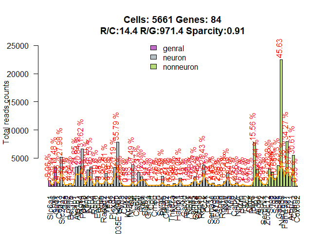

```r
## Without any selection criteria
neuron_group <- RCA_barplot(data = RCA_data,gene = marker_gene)
```

As an example , our cell selection criteria is

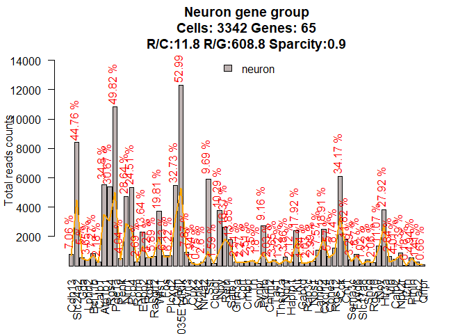

```r
## Parameter explanation
# gene.target = 2           - Select 2nd list from marker_gene, which is a list of neuronal gene
# target.min.count.cell = 2 - For Neuronal genes, minimum 2 reads/cell
# rest.min.count.cell = 2   - For rest of the genes, minimum 2 reads/cell
# at.least.gene = 1         - Cell will have at least 1 neuronal genes
# gene.show = 2             - Only consider Neuronal genes to subset data

neuron_group <- RCA_barplot(data = RCA_data, gene = marker_gene, gene.target = 2,
                            target.min.count.cell = 2, rest.min.count.cell = 2,
                            at.least.gene = 1, gene.show = 2, main = " Neuron gene group")
```

# 7 Pre-processing of RCA data

Before further analysis of RCA data, the data needs pre-processing like data scaling, centering , normlization.

## 7.1 Data normalization, scaling and centering

Normalization, scaling and centering will apply on RCA data by the function `RCA_preprocess`. Data normalization is nessary for data analysis, specially for compute PCA to reduce dimentionality. Scaled and centered data is necessary to vizualize data. [Need more focus]

```r
neuron_group <- RCA_preprocess(data = neuron_group, normalization.method = "LogNormalize",
                               do.scale = TRUE, do.center = TRUE)
```

Setting `do.center` to TRUE will center the expression for each gene by subtracting the average expression for that gene. Setting `do.scale` to TRUE will scale the expression level for each gene by dividing the centered gene expression levels by their standard deviations if `do.center` is TRUE and by their root mean square otherwise. [Need more focus and need to test on the reference] (Berg et al. 2006)

# 8 Data clustering and analysis

## 8.1 Data cluster and re-cluster

### 8.1.1 Data clustering

#### 8.1.1.1 Data clustering by SEURAT

In the previous section we have select cells based on different selection criteria on gene of interest. The dataset is as follows

```r
neuron_group
```

```
## An object of class RCA_class
## Number of genes: 65
## Number of cells: 3342
## Cluster id:
## Cluster size:
```

Now we can cluster cells by different pipeline of interest by using the function `RCA_cluster`. Available pipeline is SEURAT, BACKSPIN, MONOCLE. For details see `help(RCA_cluster)`. Output result of function `RCA_cluster` is in class `RCA_class`

```r
neuron_group_cluster  <- RCA_cluster (data = neuron_group, method = "seurat",
                                      pc = 0.9, resolution = 0.2)
neuron_group_cluster
```

```
## An object of class RCA_class
## Number of genes: 65
## Number of cells: 3342
## Cluster id: 0 1 2 3 4
## Cluster size: 1227 986 691 396 42
```

Now we can plot cells and cluster information on actual tissue to observe those results. To plot cells the following command can be used

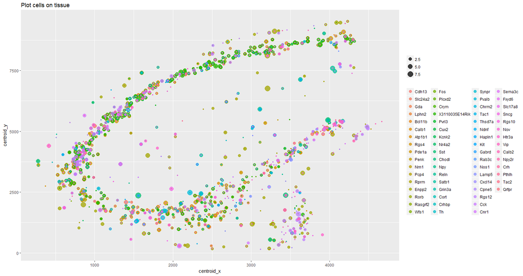

```r
RCA_map(neuron_group_cluster, what = "cell" , main = "Plot cells on tissue")
```

To plot cluster following command can be used

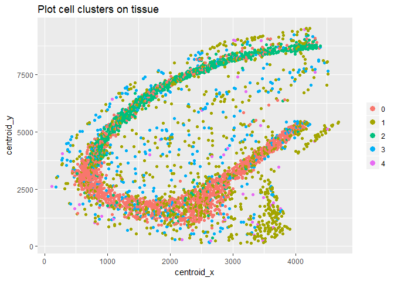

```r
RCA_map(neuron_group_cluster, what = "cluster" , main = "Plot cell clusters on tissue")
```

#### 8.1.1.2 Data clustering : Dimention reduction by tSNE

To apply tSNE, we can use following command

```r
neuron_group_cluster <- RCA_tsne(data = neuron_group_cluster, do.label = TRUE,
                                 pc= 0.9, perplexity= 100)
```

### 8.1.2 Define cluster marker

Now to find the genes those are marker or differentially expressed in individual cluster, can be identified. `RCA_marker` function can be used for this purpose.

```r
neuron_group_cluster_marker <- RCA_marker(data=neuron_group_cluster, topgene = 5 ,
                                          test.use="bimod", only.pos = TRUE,
                                          main = "Neuronal gene group")
```

```r
neuron_group_cluster_marker
```

```
## An object of class RCA_class
## Number of genes: 65
## Number of cells: 3342
## Cluster id: 0 1 2 3 4
## Cluster size: 1227 986 691 396 42
```

```r
neuron_group_cluster_marker@cluster.marker
```

```
## $`0`
##                cluster           gene
## Pde1a                0          Pde1a
## Slc24a2              0        Slc24a2
## X3110035E14Rik       0 X3110035E14Rik
## Crym                 0           Crym
## Atp1b1               0         Atp1b1
## Nrn1                 0           Nrn1
## Rgs4                 0           Rgs4
## Pcp4                 0           Pcp4
## Kit                  0            Kit
## Htr3a                0          Htr3a
## Pvrl3                0          Pvrl3
## Npy2r                0          Npy2r
## Sst                  0            Sst
##
## $`1`
##        cluster  gene
## Enpp21       1 Enpp2
## Rgs121       1 Rgs12
## Sncg1        1  Sncg
##
## $`2`
##                 cluster           gene
## X3110035E14Rik2       2 X3110035E14Rik
## Wfs12                 2           Wfs1
## Nov2                  2            Nov
## Lphn2                 2          Lphn2
## Fos                   2            Fos
##
## $`3`
##         cluster   gene
## Npy3          3    Npy
## Reln3         3   Reln
## Htr3a2        3  Htr3a
## Cxcl142       3 Cxcl14
## Satb13        3  Satb1
## Cnr13         3   Cnr1
## Cck3          3    Cck
## Pvalb3        3  Pvalb
## Rgs123        3  Rgs12
## Vip3          3    Vip
## Fxyd6         3  Fxyd6
## Ndnf3         3   Ndnf
## Lamp51        3  Lamp5
## Cdh13         3  Cdh13
## Tac1          3   Tac1
## Crhbp         3  Crhbp
## Cpne53        3  Cpne5
## Chrm2         3  Chrm2
## Tac23         3   Tac2
## Calb2         3  Calb2
##
## $`4`
##        cluster  gene
## Enpp24       4 Enpp2
```

Now to vizualize cluster marker

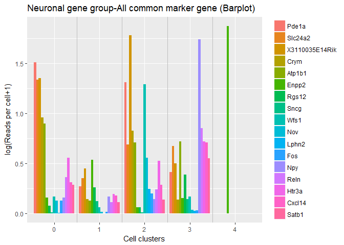

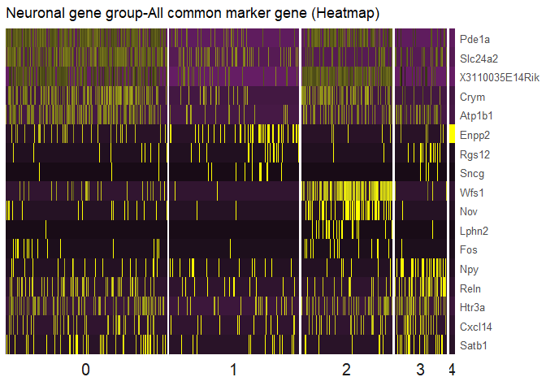

### 8.1.3 Labeling cells with cluster marker

In the previous we have identified the marker for the specific cluster. Now we can label correspondong cluster with marker gene according to their significance order.

#### 8.1.3.1 Labeling cells on tissue by marker genes

##### 8.1.3.1.1 Marker genes by cluster

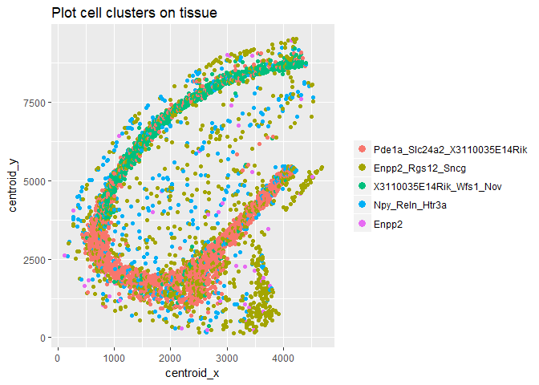

```r
RCA_map(neuron_group_cluster_marker, what = "cluster" ,
        main = "Plot cell clusters on tissue", label.topgene = 3)
```

##### 8.1.3.1.2 Top marker genes by cluster by considering expression

To plot only gene “Enpp2” to see their cluster distribution baed on expression level

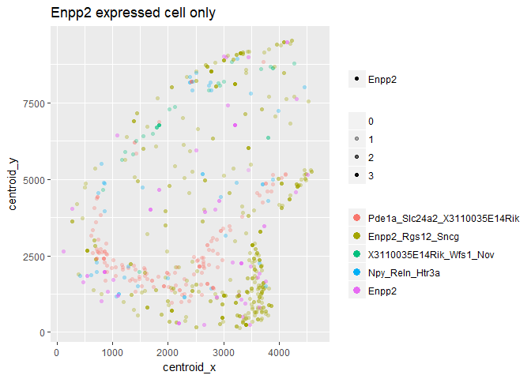

```r
RCA_map(neuron_group_cluster_marker, what = "cluster" ,
        main = "Enpp2 expressed cell only", gene = c("Enpp2"), label.topgene = 3)
```

#### 8.1.3.2 Labeling cells on tSNE cluster by marker genes

##### 8.1.3.2.1 Marker genes by cluster

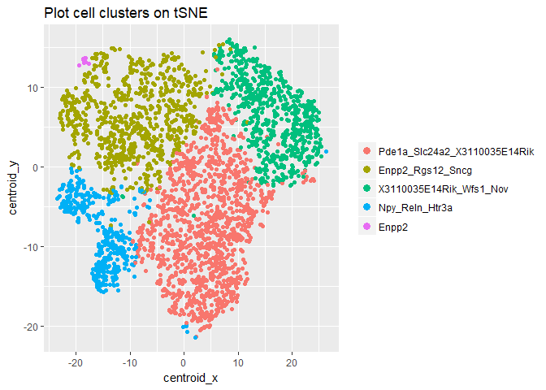

```r
RCA_map(neuron_group_cluster_marker, what = "tsne" ,
        main = "Plot cell clusters on tSNE", label.topgene = 3)
```

##### 8.1.3.2.2 Top marker genes by cluster by considering expression

To plot only gene “Enpp2” to see their cluster distribution baed on expression level

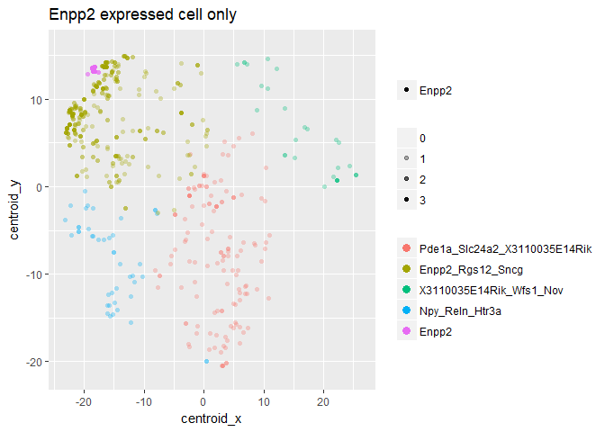

```r
RCA_map(neuron_group_cluster_marker, what = "tsne" ,
        main = "Enpp2 expressed cell only", gene = c("Enpp2"), label.topgene = 3)
```

### 8.1.4 Re-cluster a cluster

```r
neuron_group_cluster
```

```
## An object of class RCA_class
## Number of genes: 65
## Number of cells: 3342
## Cluster id: 0 1 2 3 4
## Cluster size: 1227 986 691 396 42
```

Now we can select cluster 0 to recluster it again.

```r
neuron_group_cluster_0  <- RCA_cluster (data = neuron_group_cluster, method = "seurat",cluster_id = 0,
                                      pc = 0.9, resolution = 0.1)
```

```r
neuron_group_cluster_0
```

```
## An object of class RCA_class
## Number of genes: 65
## Number of cells: 1227
## Cluster id: 0 1 2 3
## Cluster size: 483 418 196 130
```

Now to plot cells

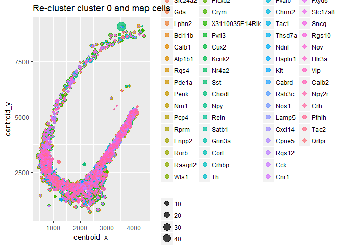

```r
RCA_map(neuron_group_cluster_0, what = "cell" , main = "Re-cluster cluster 0 and map cells")
```

To plot cluster

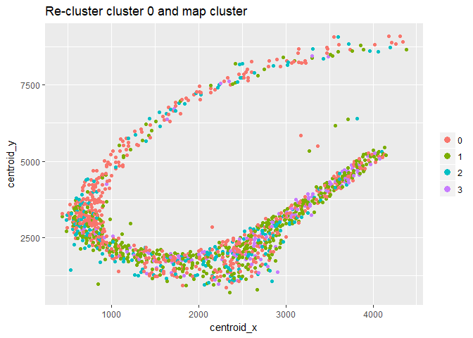

```r
RCA_map(neuron_group_cluster_0, what = "cluster" , main = "Re-cluster cluster 0 and map cluster")
```

To define cluster marker

```r
neuron_group_cluster_0_marker <- RCA_marker(data=neuron_group_cluster_0, topgene = 5,
                                          test.use="bimod", only.pos = TRUE,
                                          main = "Neuronal gene group: Cluster 0")
```

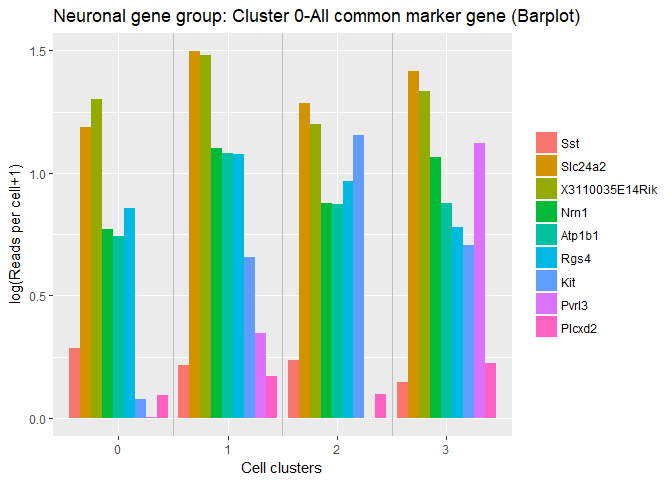

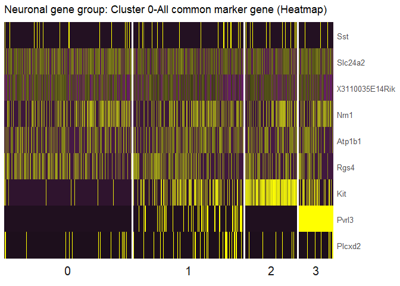

```r
neuron_group_cluster_0_marker
```

```
## An object of class RCA_class
## Number of genes: 65
## Number of cells: 1227
## Cluster id: 0 1 2 3
## Cluster size: 483 418 196 130
```

To label cell cluster with marker gene

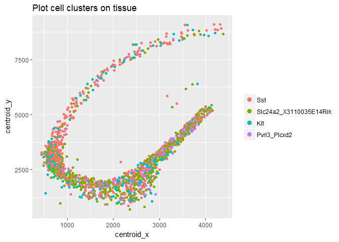

```r
RCA_map(neuron_group_cluster_0_marker, what = "cluster" ,
        main = "Plot cell clusters on tissue", label.topgene = 2)
```

To label tSNE cluster with marker gene

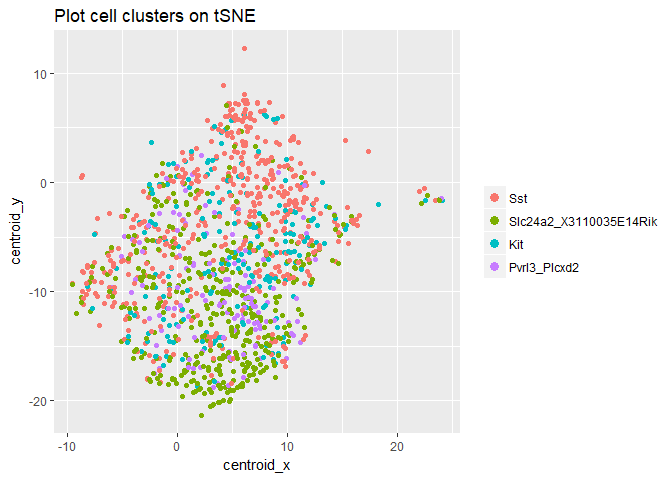

```r
RCA_map(neuron_group_cluster_0_marker, what = "tsne" ,
        main = "Plot cell clusters on tSNE", label.topgene = 2)
```

## 8.2 Cluster compare and validation : An example

```r
## Read data: Left and right HC
hc_left  <- readRCA(file = system.file("extdata", "Hypocampus_left.csv", package="MolDia"),
                   cellid = "CellId",centX = "centroid_x", centY = "centroid_y")
hc_right <- readRCA(file = system.file("extdata", "Hypocampus_right.csv", package="MolDia"),
                   cellid = "CellId",centX = "centroid_x", centY = "centroid_y")
```

```r
## Arrange marker gene
data(marker_gene)
marker_gene <- marker_gene
mark_gene <- list(genr = marker_gene$genr, neuron = c(marker_gene$genr_neuro,
                                                       marker_gene$genr_neuro_pyra1,
                                                       marker_gene$genr_neuro_pyra2,
                                                       marker_gene$genr_neuro_inter1,
                                                       marker_gene$genr_neuro_inter2,
                                                       marker_gene$genr_neuro_inter3,
                                                       marker_gene$genr_neuro_inter4,
                                                       marker_gene$genr_neuro_inter5,
                                                       marker_gene$genr_neuro_inter6),
                                             nonneuron = marker_gene$genr_nonneuro)
```

```r
## Select cell : Barplot of Neuronal marker gene and extract those cells only
hc_left  <- RCA_barplot(data = hc_left, gene = mark_gene, gene.target = 2,
                             at.least.gene = 2, gene.show = 2)
hc_right <- RCA_barplot(data = hc_right, gene = mark_gene, gene.target = 2,
                             at.least.gene = 2, gene.show = 2)
```

```r
## Data preprocessing
hc_left  <- RCA_preprocess(data = hc_left, normalization.method = "LogNormalize",
                                do.scale = TRUE, do.center = TRUE)
hc_right <- RCA_preprocess(data = hc_right, normalization.method = "LogNormalize",
                                do.scale = TRUE, do.center = TRUE)
```

```r
## Cluster data based on SEURAT pipeline
hc_left   <- RCA_cluster(data =  hc_left, pc = 0.9, resolution = 0.3, method = "seurat")
hc_right  <- RCA_cluster(data = hc_right, pc = 0.9, resolution = 0.4, method = "seurat")
```

```r
## Dimention reduction by tSNE on clustered data
hc_left   <- RCA_tsne(data = hc_left, do.label = TRUE, pc= 0.9, perplexity= 100)
hc_right  <- RCA_tsne(data = hc_right, do.label = TRUE, pc= 0.9, perplexity= 100)
```

```r
## Get cluster marker
hc_left  <- RCA_marker(data = hc_left, topgene =5, test.use="bimod",
                       main = "hc_left")
```

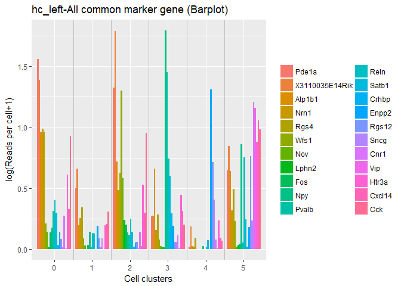

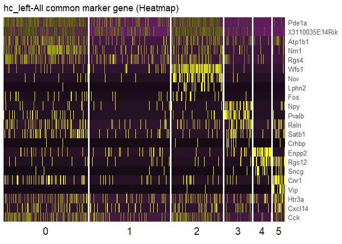

```r
hc_right <- RCA_marker(data = hc_right, topgene =5, test.use="bimod",
                       main = "hc_right")
```

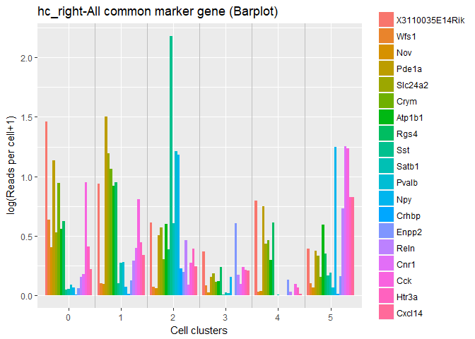

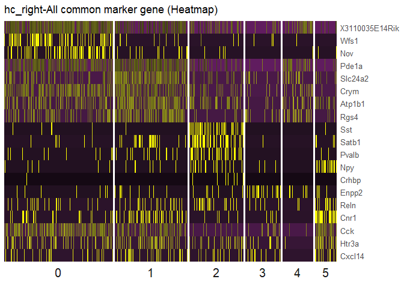

```r
RCA_map (data = hc_left, what = "tsne",  label.topgene =2, main = "hc_left")
```

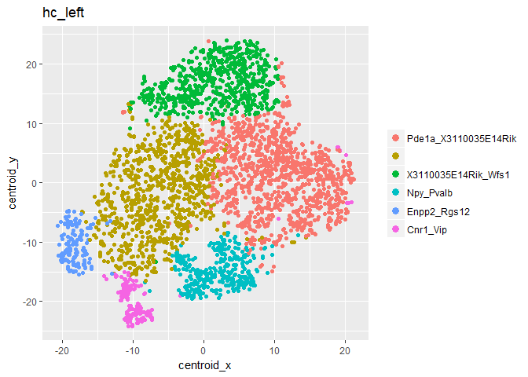

```r
RCA_map (data = hc_right, what = "tsne", label.topgene =2, main = "hc_right")
```

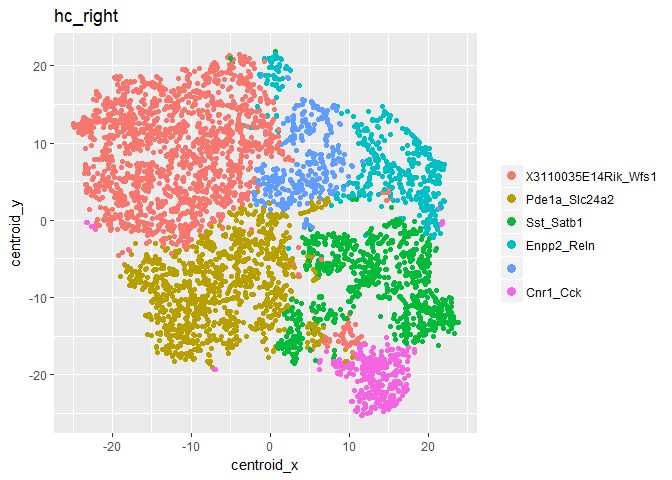

```r
## Cluster compare
my_comapre_1 <- RCA_clustcompare(preditorData = hc_left, prediction = hc_right)
```

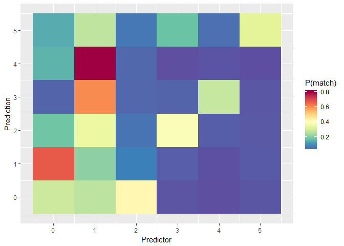

```r
my_comapre_2 <- RCA_clustcompare(preditorData = hc_right, prediction = hc_left)
```

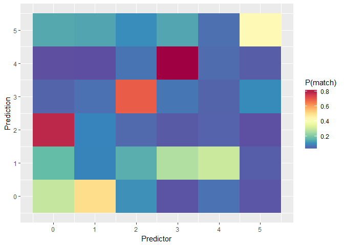

# 9 Citation

```
##
##
##   Mats Nilsson (2017). MolDia: Single cell In-Situ RCA data
##   analysis. R package version 0.0.1.
##
## A BibTeX entry for LaTeX users is
##
##   @Manual{,
##     title = {MolDia: Single cell In-Situ RCA data analysis},
##     author = {Mats Nilsson},
##     year = {2017},
##     note = {R package version 0.0.1},
##   }
##
## ATTENTION: This citation information has been auto-generated from
## the package DESCRIPTION file and may need manual editing, see
## 'help("citation")'.
```

# Reference

Berg, Robert A. van den, Huub CJ Hoefsloot, Johan A. Westerhuis, Age K. Smilde, and Mariët J. van der Werf. 2006. “Centering, Scaling, and Transformations: Improving the Biological Information Content of Metabolomics Data.” *BMC Genomics* 7 (1): 142. doi:10.1186/1471-2164-7-142.